# PAWS Datathon Submission Form

R-Ladies

March 24, 2019

## Executive Summary

- @phillypaws tweets were analyzed to understand any patterns in twitter activity and whether that could be linked to application or pet information
- No strong trends or observations were gained, but it was fun to look at the data
- We did not see a strong association between twitter activity and applications
- We identified the most commonly tweeted words such as “home”, “adoption”, and “meet”
- We found that tweets with photos were more often favorited and retweeted

## Contributors

**Alice M Walsh, PhD** is a computational biologist in the pharmaceutical industry. She enjoys analyzing patient data and trying to make informed decisions using data. She also enjoys walking and training her dog, Pebbles.

## Problem definition and dataset

We examined the data from the PAWS twitter account, @phillypaws. We used the twitter API to download the most recent 3200 tweets, which included all tweets from 2018. Quotes and retweets were not excluded from the dataset.

## Results

```r
# Load in data - previously pulled with rtweet package
tweets <- readRDS('tweets_13FEB2019.Rds')
# Let's focus on 2018 to match other datasets
tweets_18 <- filter(tweets, created_at < as.Date("2019-01-01"), created_at > as.Date("2018-01-01"))
```

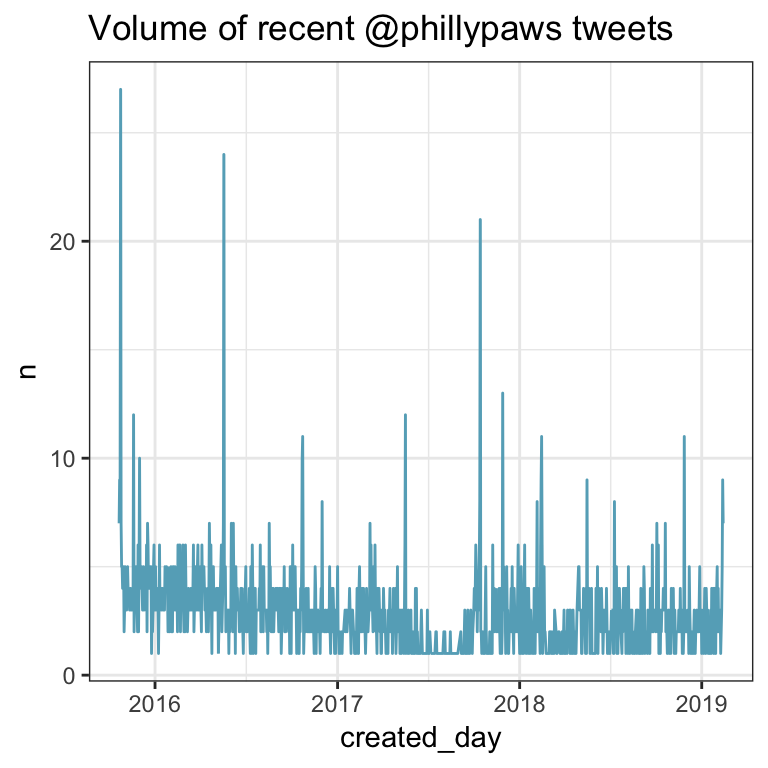

```r
tweets %>%
  mutate(created_day = lubridate::floor_date(created_at, unit = "day")) %>%
  count(created_day) %>%
  ggplot(aes(x=created_day, y=n)) +
  geom_line() +
  theme_bw() +
  ggtitle("Volume of recent @phillypaws tweets")
```

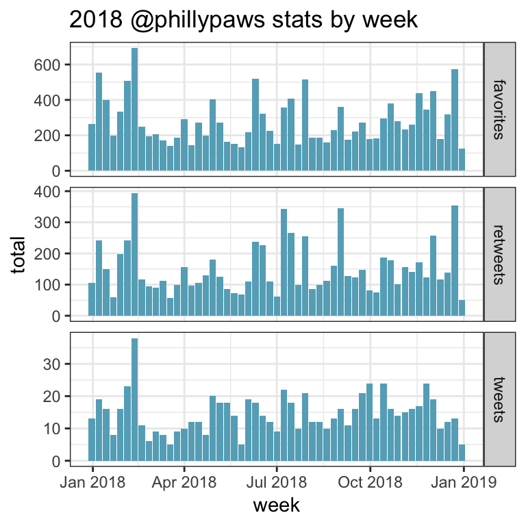

```r
# Let's count tweets by day-of-the-week, week, month, and look for trends
# Plot by week:
tweets_18 %>%
  mutate(week = lubridate::floor_date(created_at, unit = "week")) %>%
  group_by(week) %>%
  summarise(favorites = sum(favorite_count),
            tweets = n(),
            retweets = sum(retweet_count)) %>%
  gather(metric, total, favorites:retweets) %>%
  ggplot(aes(x=week, y=total)) +
  geom_col() +
  facet_grid(metric~., scales = "free") +
  theme_bw() +
  ggtitle("2018 @phillypaws stats by week")
```

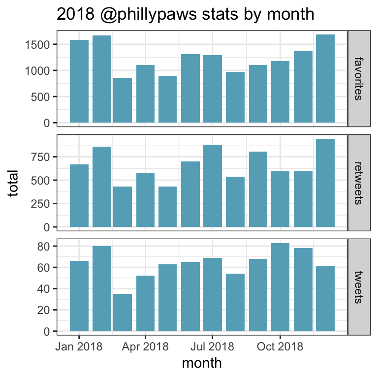

```r
# Plot by month:
tweets_18 %>%
  mutate(month = lubridate::floor_date(created_at, unit = "month")) %>%
  group_by(month) %>%
  summarise(favorites = sum(favorite_count),
            tweets = n(),
            retweets = sum(retweet_count)) %>%
  gather(metric, total, favorites:retweets) %>%
  ggplot(aes(x=month, y=total)) +
  geom_col() +
  facet_grid(metric~., scales = "free") +
  theme_bw() +
  ggtitle("2018 @phillypaws stats by month")
```

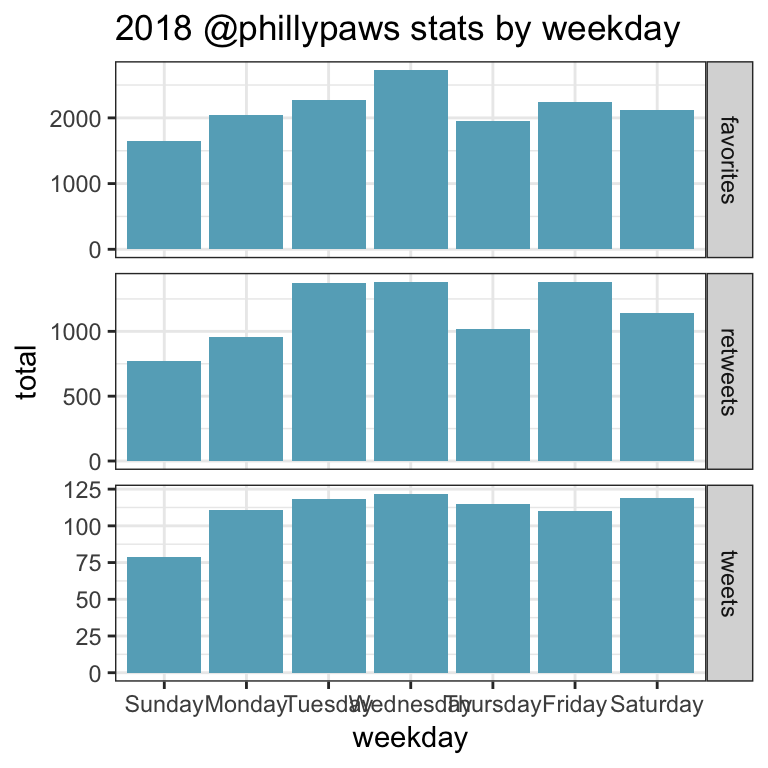

```r
# Plot by day-of-the-week:
tweets_18 %>%
  mutate(weekday = weekdays(created_at)) %>%
  mutate(weekday = factor(weekday,
                               levels = c("Sunday","Monday","Tuesday","Wednesday","Thursday","Friday","Saturday"))) %>%
  group_by(weekday) %>%
  summarise(favorites = sum(favorite_count),
            tweets = n(),
            retweets = sum(retweet_count)) %>%
  gather(metric, total, favorites:retweets) %>%
  ggplot(aes(x=weekday, y=total)) +
  geom_col() +
  facet_grid(metric~., scales = "free") +
  theme_bw() +
  ggtitle("2018 @phillypaws stats by weekday")
```

```r
# Compare twitter activity to application activity?
cat_apps <- read.csv('../../Data/cat_apps.csv',
                     na.strings = c(" ","","na","NA"), stringsAsFactors = F)%>%
  janitor::clean_names() %>%
  mutate(date_submitted = as.Date(date_submitted, "%m/%d/%Y"))

dog_apps <- read.csv('../../Data/dog_apps.csv',
                     na.strings = c(" ","","na","NA"), stringsAsFactors = F)%>%
  janitor::clean_names() %>%
  mutate(date_submitted = as.Date(date_submitted, "%m/%d/%Y"))

compare_cat_apps <- cat_apps %>%
  count(date_submitted) %>%
  mutate(type = "cat_apps") %>%
  rename(created_day = date_submitted)

compare_dog_apps <- dog_apps %>%
  count(date_submitted) %>%
  mutate(type = "dog_apps") %>%
  rename(created_day = date_submitted)

compare_tweets <- tweets_18 %>%
  mutate(created_day = lubridate::floor_date(created_at, unit = "day")) %>%
  filter(created_day >= min(compare_cat_apps$created_day)) %>%
  count(created_day) %>%
  mutate(type = "tweets")

compare_days  <- rbind(compare_tweets, compare_cat_apps, compare_dog_apps)
```

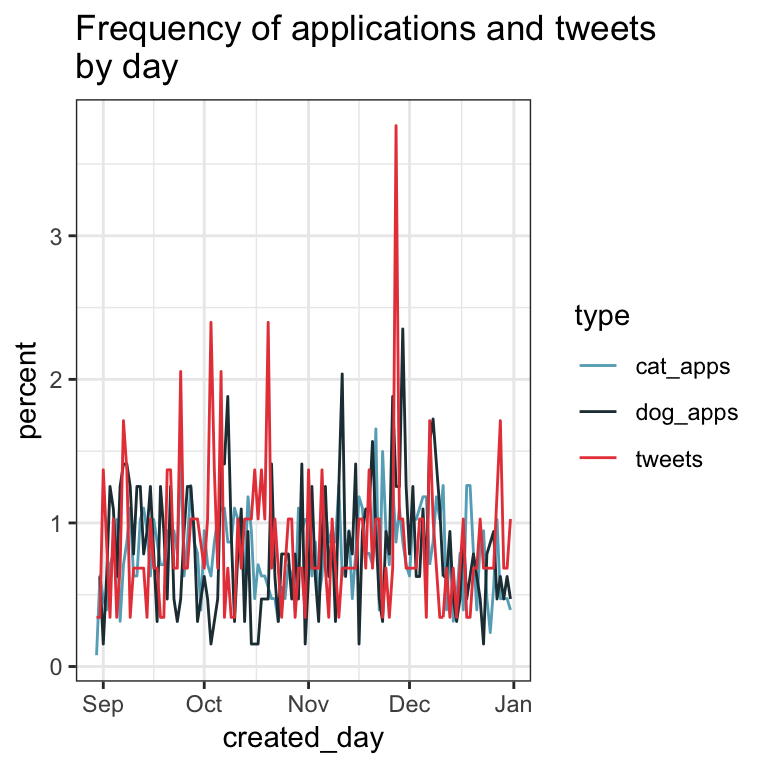

```r
# Line by day
compare_days %>%
  group_by(type) %>%
  mutate(percent = n/sum(n) * 100) %>%
  ggplot(aes(x=created_day, y=percent, color=type)) +
  geom_line() +
  theme_bw()+
  ggtitle("Frequency of applications and tweets \nby day")
```

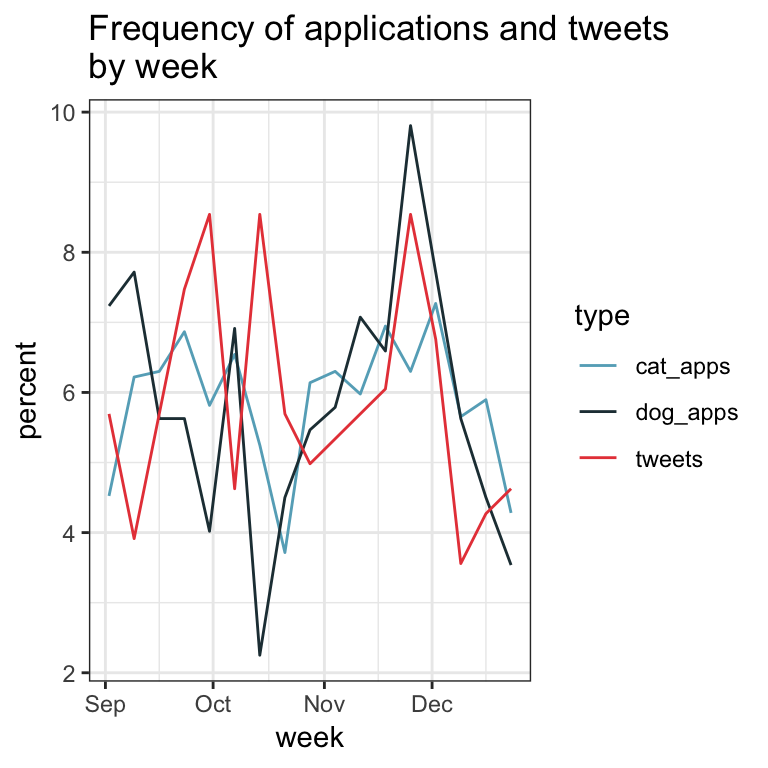

```r
# Line by week
compare_days %>%
  # remove the short week - 2018-08-26 and 2018-12-30
  filter(created_day > as.Date("2018-09-02"), created_day < as.Date("2018-12-30")) %>%
  mutate(week = lubridate::floor_date(created_day, unit = "week")) %>%
  group_by(type, week) %>%
  summarise(total = sum(n)) %>%
  mutate(percent = total/sum(total) * 100) %>%
  ggplot(aes(x=week, y = percent)) +
  # geom_bar(aes(fill = type), position="dodge", stat = "identity") +
  geom_line(aes(color = type))+
  theme_bw() +
  ggtitle("Frequency of applications and tweets \nby week")
```

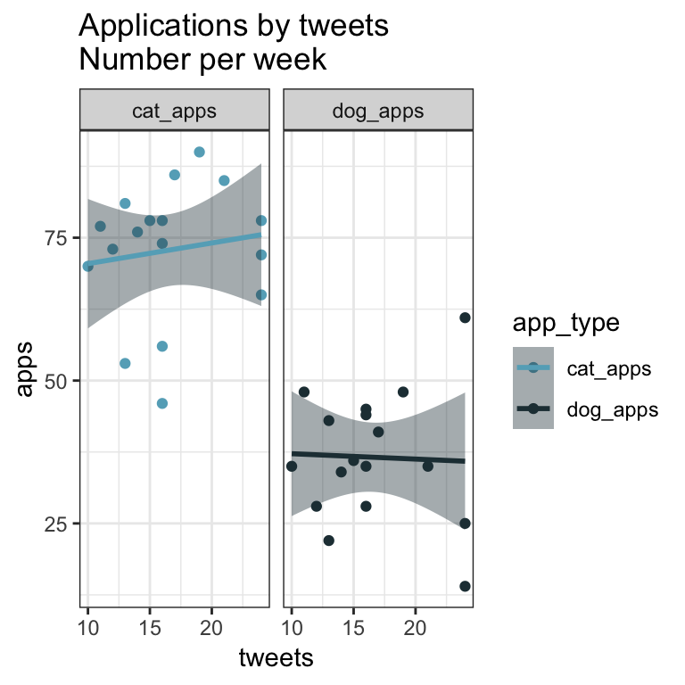

```r
# Scatter plot grouped by week
compare_days %>%
  # remove the short week - 2018-08-26 and 2018-12-30
  filter(created_day > as.Date("2018-09-02"), created_day < as.Date("2018-12-30")) %>%
  mutate(week = lubridate::floor_date(created_day, unit = "week")) %>%
  group_by(type, week) %>%
  summarise(total = sum(n)) %>%
  ungroup() %>%
  tidyr::spread(key = type, value = total) %>%
  tidyr::gather(app_type, apps, cat_apps:dog_apps) %>%
  ggplot(aes(x=tweets, y = apps, color=app_type)) +
  geom_point() +
  geom_smooth(method = "lm") +
  facet_wrap(~app_type) +
  theme_bw() +
  ggtitle("Applications by tweets\nNumber per week")
```

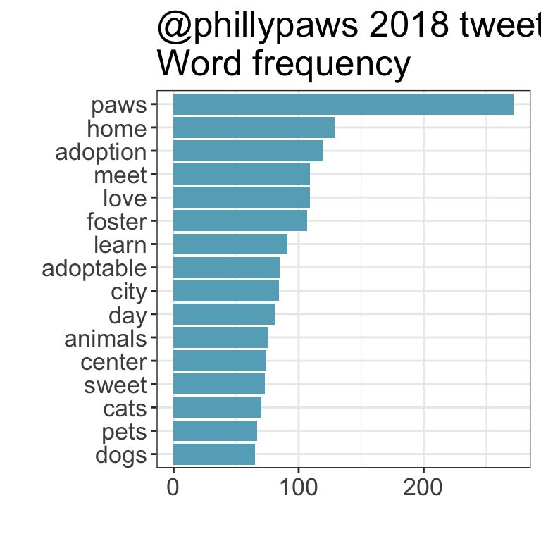

```r
# What are the top words in all the tweets?
# Wrote a function to plot for a given dataset
# thanks to https://www.williamrchase.com/post/is-hadley-wickham-a-cat-or-dog-person-a-twitter-tidytext-analysis/
source('alice_plot_top_words.R')

# plot_top_words(tweets)
plot_top_words(tweets_18) + ggtitle("@phillypaws 2018 tweets\nWord frequency") + theme_bw() + xlab("") + ylab("") + theme(text = element_text(size=16))
```

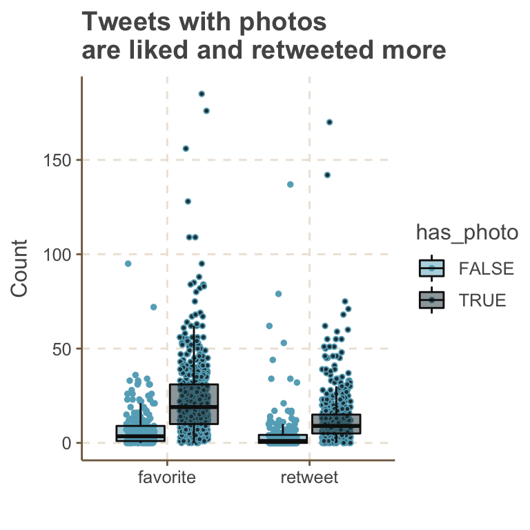

```r
tweets_18 %>%
  mutate(has_photo = !is.na(media_type)) %>%
  gather(metric, count, favorite_count:retweet_count) %>%
  mutate(metric = gsub("_count","",metric)) %>%
  ggplot(aes(x=metric, y=count, fill = has_photo)) +
  geom_point(pch=21, size=1,
             position = position_jitterdodge(jitter.width = 0.2, jitter.height = 0)) +
  geom_boxplot(alpha = 0.5, outlier.shape = NA) +
  ylab("Count") + xlab("") +
  ggtitle("Tweets with photos \nare liked and retweeted more")
```

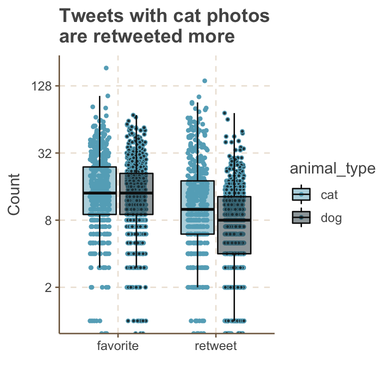

```r
# Merge in cat/dog predictions
pred_img <- readRDS('alice_predict.Rds')
pred_img <- pred_img %>%
  mutate(status_id = gsub(".jpg","",gsub("predict/","",filenames)))

tweets_pred <- tweets %>%
  left_join(pred_img, by = "status_id") %>%
  mutate(has_photo = !is.na(media_type)) %>%
  # filter(has_photo == T) %>%
  mutate(animal_type = case_when(
    predict < 0.2 ~ "cat",
    predict > 0.9 ~ "dog",
    is.na(predict) ~ "no photo",
    TRUE ~ "other"
  ),
  animal_text = case_when(
    grepl("cat|kitten|Cat|Kitten", text) ~ "cat",
    grepl("dog|pup|Dog|Pup", text) ~ "dog",
    TRUE ~ "other"
  )) %>%
  filter(is_quote == F, is_retweet == F)


tweets_pred %>%
  filter(animal_type %in% c("cat","dog")) %>%
  # filter(retweet_count < 200) %>%
  gather(metric, count, favorite_count:retweet_count) %>%
  mutate(metric = gsub("_count","",metric)) %>%
  ggplot(aes(x=metric, y=count, fill = animal_type)) +
  geom_point(pch=21, size=1,
             position = position_jitterdodge(jitter.width = 0.2, jitter.height = 0)) +
  geom_boxplot(alpha = 0.5, outlier.shape = NA) +
  scale_y_continuous(trans = "log2") +
  # ylim(c(0,100)) +
  ylab("Count") + xlab("") +
  ggtitle("Tweets with cat photos \nare retweeted more")
```

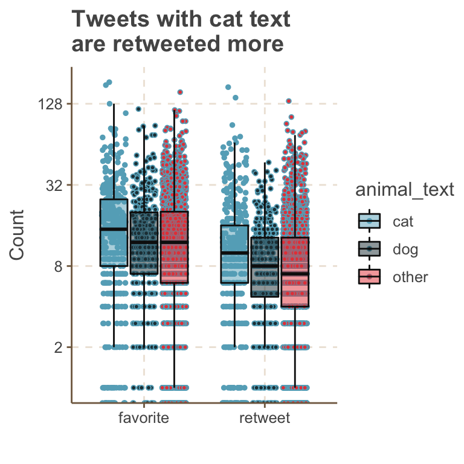

```r
tweets_pred %>%
  # filter(animal_type %in% c("cat","dog")) %>%
  # filter(retweet_count < 200) %>%
  gather(metric, count, favorite_count:retweet_count) %>%
  mutate(metric = gsub("_count","",metric)) %>%
  ggplot(aes(x=metric, y=count, fill = animal_text)) +
  geom_point(pch=21, size=1,
             position = position_jitterdodge(jitter.width = 0.2, jitter.height = 0)) +
  geom_boxplot(alpha = 0.5, outlier.shape = NA) +
  # ylim(c(0,100)) +
  scale_y_continuous(trans = "log2") +
  ylab("Count") + xlab("") +
  ggtitle("Tweets with cat text \nare retweeted more")
```

## Conclusions and Next Steps

Keep on tweeting! If someone wanted to dig deeper into this data, they could:

- Perform better image analysis on photos tweeted
- Try to link tweets about certain topics (a specific animal, request for donations) to specific outcomes (did the animal get adopted? did they receive more donations?)